# HW2

Dan Fanelli

February 20, 2017

## Module 2: NYC Buildings Data Analysis

A Look at the NYC Buildings Data

| Borough | LotArea | BldgArea | NumBldgs | NumFloors | YearBuilt | YearAlter1 | YearAlter2 | AssessTot |
| --- | --- | --- | --- | --- | --- | --- | --- | --- |
| BK | 151930 | 0 | 0 | 0 | 0 | 0 | 0 | 1164645 |
| BK | 19682 | 154400 | 1 | 9 | 1920 | 1994 | 2007 | 12019950 |
| BK | 0 | 102534 | 1 | 12 | 0 | 0 | 0 | 5864853 |
| BK | 387060 | 0 | 15 | 0 | 0 | 0 | 0 | 0 |
| BK | 6384 | 0 | 0 | 0 | 0 | 0 | 0 | 21150 |
| BK | 0 | 0 | 0 | 0 | 0 | 0 | 0 | 1800 |

# Q1: Accuracy of the Building History Data

*Build a graph to help the city determine when most buildings were constructed. Is there anything in the results that causes you to question the accuracy of the data? ? (note: only look at buildings built since 1850)*

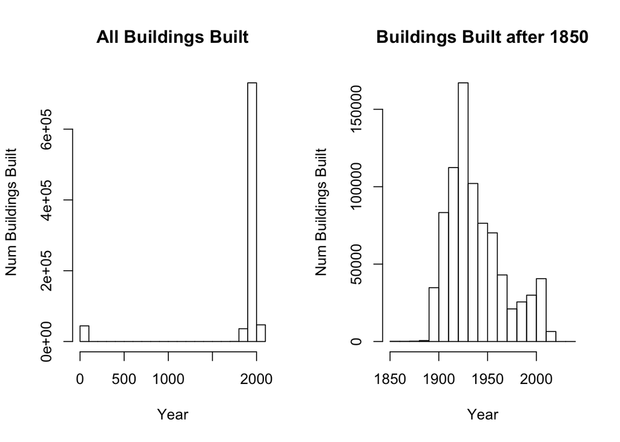

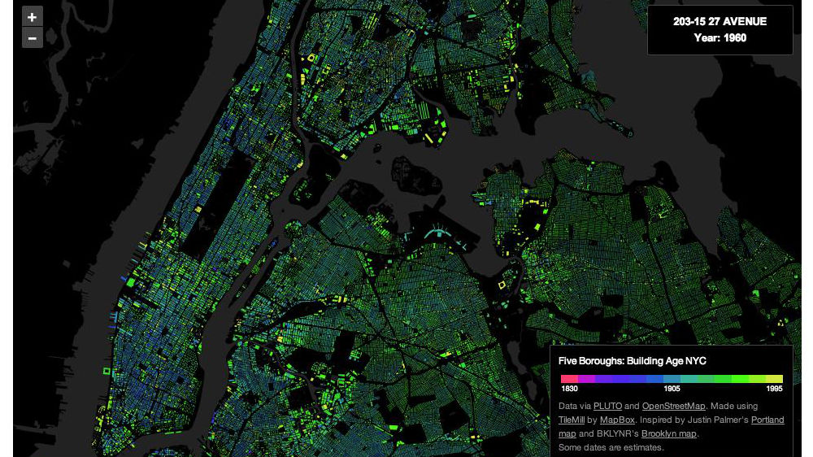

The NYC population by year would probably correlate to the total number of floors by year, and wikipedia’s [Demographic history of New York City](https://en.wikipedia.org/wiki/Demographic_history_of_New_York_City) tells us that the NYC population growth did in fact level off around mid-century. (See image below)

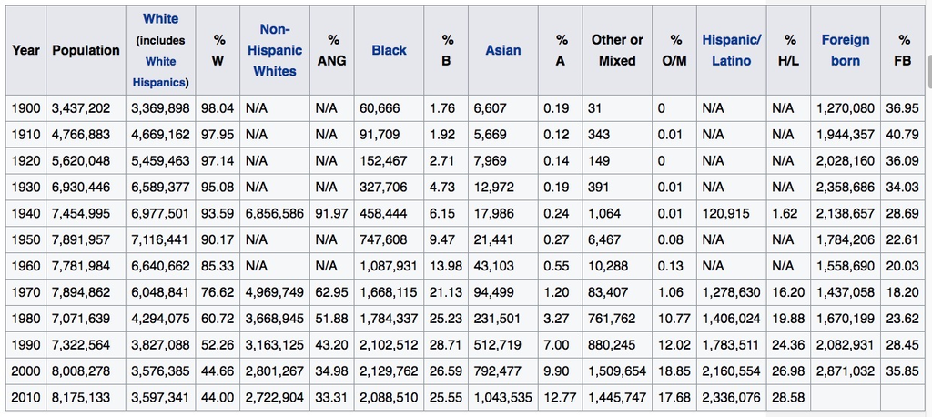

Therefore, aside from data such as NumFloors being zero, it seems that this data is realistic.

## Q2: Number of Floors by Year

*The city is particularly worried about buildings that were unusually tall when they were built, since best-practices for safety hadn’t yet been determined. Create a graph that shows how many buildings of a certain number of floors were built in each year (note: you may want to use a log scale for the number of buildings). It should be clear when 20-story buildings, 30-story buildings, and 40-story buildings were first built in large numbers.*

Floors by Decade with Log10

|  | years_tens | floors_tens | the_count | log_count |
| --- | --- | --- | --- | --- |
| 90 | 2010 | 50 | 9 | 0.9542425 |
| 91 | 2010 | 60 | 8 | 0.9030900 |
| 92 | 2010 | 70 | 1 | 0.0000000 |
| 93 | 2010 | 80 | 3 | 0.4771213 |
| 94 | 2010 | 90 | 1 | 0.0000000 |
| 95 | 2040 | 0 | 1 | 0.0000000 |

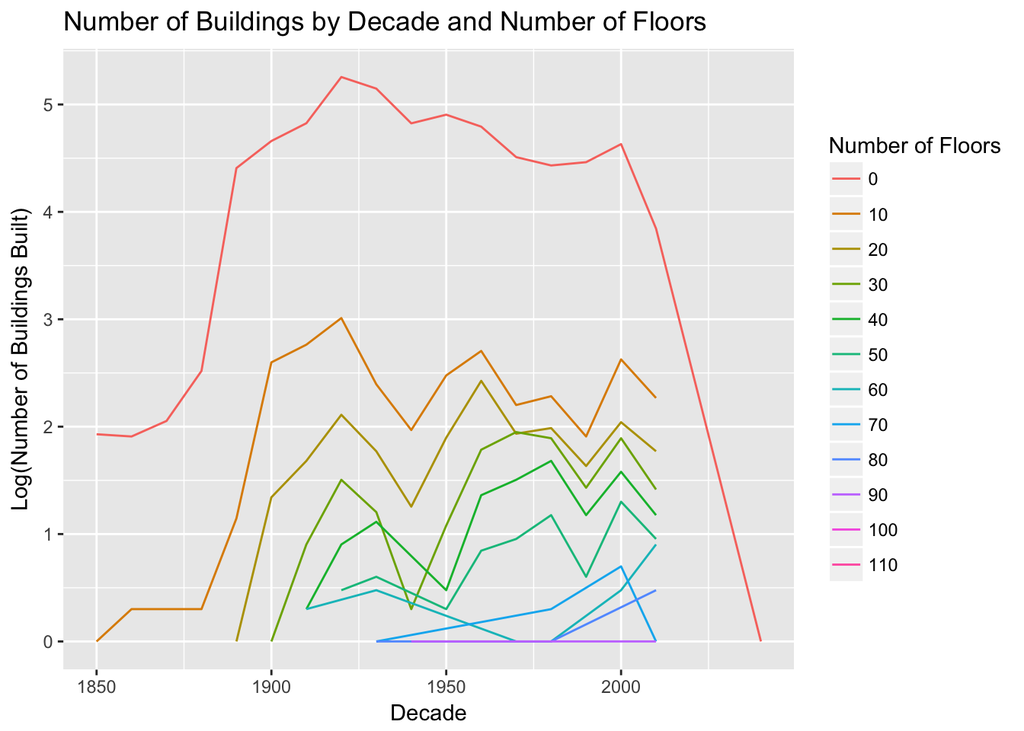

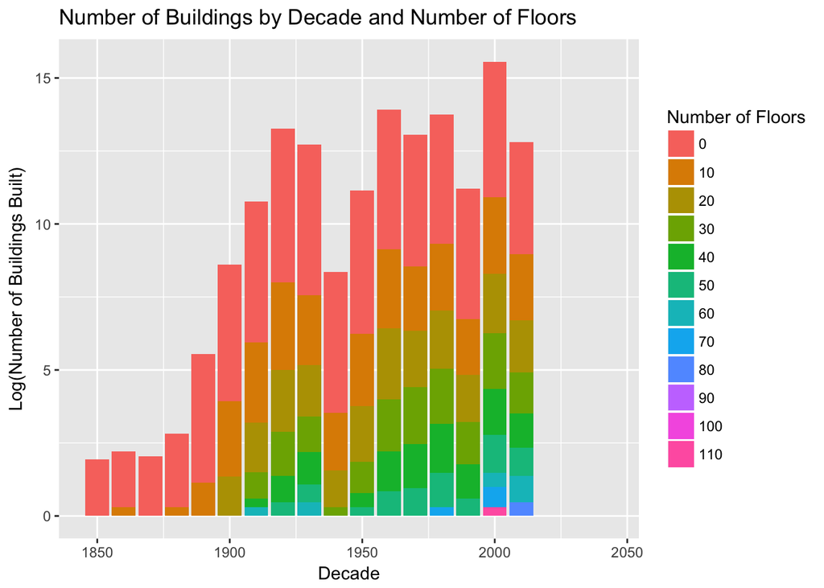

Bear in mind that we have removed the zero floor rows initially from the data, so these zero floors really are showing us buildings with floors 1-9, and the floor() function translated these to zero, ie less than 10.

## Q3: Value per floor per year

*Your boss suspects that buildings constructed during the US’s involvement in World War II (1941-1945) are more poorly constructed than those before and after the war due to the high cost of materials during those years. She thinks that, if you calculate assessed value per floor, you will see lower values for buildings at that time vs before or after. Construct a chart/graph to see if she’s right.*

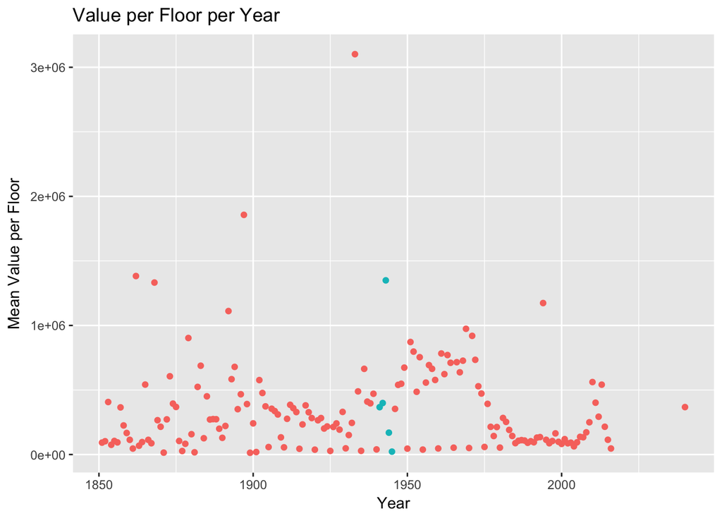

In this case, I would tell my boss that her conclusion is not validated by this data.